# INN_Learner_Notebook_Full_code_version_FINAL_Amardeep_v05

### Neural Network with Balanced Data (by applying SMOTE), Adam Optimizer, Dropout and Batch Normalization

```python
# Clear the session and fix the random number seed
tf.keras.backend.clear_session()
np.random.seed(42)
random.seed(42)
tf.random.set_seed(42)

# Setup the NN archicature with no drop out; This time we will use tanh activation ( The relu activation was tried offline on this model architecture but it dod not yield good results)
model_5 = Sequential()

model_5.add(Dense(128, activation='tanh', kernel_initializer='glorot_uniform', input_dim = X_train.shape[1]))  # First hidden layer with 128 neurons and relu activation function
model_5.add(Dropout(0.75))                                     # Switching 75% of neurons off randomly at each iteration to avoid overfitting
model_5.add(BatchNormalization())

model_5.add(Dense(128, activation='tanh',kernel_initializer='glorot_uniform'))                     # Second hidden layer with 128 neurons and relu activation function
model_5.add(Dropout(0.75))                                     # Switching 75% of neurons off randomly at each iteration to avoid overfitting
model_5.add(BatchNormalization())

model_5.add(Dense(128, activation='tanh',kernel_initializer='glorot_uniform'))                     # Third hidden layer with 128 neurons and relu activation function
model_5.add(Dropout(0.75))                                     # Switching 75% of neurons off randomly at each iteration to avoid overfitting
model_5.add(BatchNormalization())

model_5.add(Dense(64, activation='tanh',kernel_initializer='glorot_uniform'))                     # Fourth hidden layer with 64 neurons and relu activation function
model_5.add(BatchNormalization())

model_5.add(Dense(1, activation='sigmoid'))                   # Output layer

# Define the optimization parameters and compile the model
optimizer_adam = tf.keras.optimizers.Adam(learning_rate=0.0005) # SGD optiizer
metric_R = keras.metrics.Recall()
loss_fuc = 'binary_crossentropy'
model_5.compile(loss = loss_fuc, optimizer = optimizer_adam, metrics=metric_R)
model_5.summary()
```

```
Model: "sequential"
_________________________________________________________________
 Layer (type)                Output Shape              Param #
=================================================================
 dense (Dense)               (None, 128)               1536

 dropout (Dropout)           (None, 128)               0

 batch_normalization (Batch  (None, 128)               512
 Normalization)

 dense_1 (Dense)             (None, 128)               16512

 dropout_1 (Dropout)         (None, 128)               0

 batch_normalization_1 (Bat  (None, 128)               512
 chNormalization)

 dense_2 (Dense)             (None, 128)               16512

 dropout_2 (Dropout)         (None, 128)               0

 batch_normalization_2 (Bat  (None, 128)               512
 chNormalization)

 dense_3 (Dense)             (None, 64)                8256

 batch_normalization_3 (Bat  (None, 64)                256
 chNormalization)

 dense_4 (Dense)             (None, 1)                 65

=================================================================
Total params: 44673 (174.50 KB)
Trainable params: 43777 (171.00 KB)
Non-trainable params: 896 (3.50 KB)
_________________________________________________________________
```

```python
#Fit the neural network on the train and validation sets
#retain the same batch size and epochs as earlier
batch_size = 32
epochs = 100

start = time.time()
history_5 = model_5.fit(X_train_over, y_train_over, validation_data=(X_val,y_val) , batch_size=batch_size, epochs=epochs, verbose=2)
end = time.time()
```

```
284/284 - 6s - loss: 0.7430 - recall: 0.5371 - val_loss: 0.5811 - val_recall: 0.6693 - 6s/epoch - 21ms/step
284/284 - 1s - loss: 0.6609 - recall: 0.6196 - val_loss: 0.6270 - val_recall: 0.6615 - 1s/epoch - 4ms/step
284/284 - 1s - loss: 0.6399 - recall: 0.6536 - val_loss: 0.6458 - val_recall: 0.6744 - 1s/epoch - 4ms/step
284/284 - 1s - loss: 0.6118 - recall: 0.6752 - val_loss: 0.6891 - val_recall: 0.6718 - 1s/epoch - 5ms/step
284/284 - 1s - loss: 0.6048 - recall: 0.6836 - val_loss: 0.6785 - val_recall: 0.6873 - 1s/epoch - 5ms/step
284/284 - 1s - loss: 0.5896 - recall: 0.6911 - val_loss: 0.6845 - val_recall: 0.6951 - 1s/epoch - 5ms/step
284/284 - 2s - loss: 0.5897 - recall: 0.7021 - val_loss: 0.6961 - val_recall: 0.6977 - 2s/epoch - 7ms/step
284/284 - 2s - loss: 0.5795 - recall: 0.7173 - val_loss: 0.6723 - val_recall: 0.6977 - 2s/epoch - 7ms/step
284/284 - 1s - loss: 0.5827 - recall: 0.7132 - val_loss: 0.6755 - val_recall: 0.7054 - 1s/epoch - 5ms/step
284/284 - 1s - loss: 0.5794 - recall: 0.7282 - val_loss: 0.6440 - val_recall: 0.7003 - 1s/epoch - 5ms/step
284/284 - 1s - loss: 0.5786 - recall: 0.7229 - val_loss: 0.6795 - val_recall: 0.7003 - 1s/epoch - 5ms/step
284/284 - 1s - loss: 0.5744 - recall: 0.7229 - val_loss: 0.6453 - val_recall: 0.6899 - 1s/epoch - 5ms/step
284/284 - 1s - loss: 0.5695 - recall: 0.7346 - val_loss: 0.6350 - val_recall: 0.6925 - 1s/epoch - 5ms/step
284/284 - 1s - loss: 0.5674 - recall: 0.7376 - val_loss: 0.6533 - val_recall: 0.6925 - 1s/epoch - 5ms/step
284/284 - 1s - loss: 0.5727 - recall: 0.7383 - val_loss: 0.6472 - val_recall: 0.6925 - 1s/epoch - 5ms/step
284/284 - 2s - loss: 0.5697 - recall: 0.7335 - val_loss: 0.6744 - val_recall: 0.6977 - 2s/epoch - 7ms/step
284/284 - 2s - loss: 0.5703 - recall: 0.7401 - val_loss: 0.6702 - val_recall: 0.6977 - 2s/epoch - 7ms/step
284/284 - 1s - loss: 0.5634 - recall: 0.7368 - val_loss: 0.6645 - val_recall: 0.7003 - 1s/epoch - 5ms/step
284/284 - 1s - loss: 0.5613 - recall: 0.7462 - val_loss: 0.6520 - val_recall: 0.6925 - 1s/epoch - 5ms/step
284/284 - 1s - loss: 0.5679 - recall: 0.7443 - val_loss: 0.6522 - val_recall: 0.7132 - 1s/epoch - 5ms/step
284/284 - 1s - loss: 0.5663 - recall: 0.7396 - val_loss: 0.6347 - val_recall: 0.7054 - 1s/epoch - 5ms/step
284/284 - 1s - loss: 0.5645 - recall: 0.7471 - val_loss: 0.6301 - val_recall: 0.6977 - 1s/epoch - 5ms/step
284/284 - 1s - loss: 0.5614 - recall: 0.7462 - val_loss: 0.6560 - val_recall: 0.7054 - 1s/epoch - 5ms/step
284/284 - 1s - loss: 0.5652 - recall: 0.7429 - val_loss: 0.6571 - val_recall: 0.7106 - 1s/epoch - 5ms/step
284/284 - 2s - loss: 0.5631 - recall: 0.7474 - val_loss: 0.6328 - val_recall: 0.6899 - 2s/epoch - 7ms/step
284/284 - 2s - loss: 0.5632 - recall: 0.7471 - val_loss: 0.6229 - val_recall: 0.6951 - 2s/epoch - 7ms/step
284/284 - 1s - loss: 0.5605 - recall: 0.7482 - val_loss: 0.6376 - val_recall: 0.7028 - 1s/epoch - 5ms/step
284/284 - 1s - loss: 0.5601 - recall: 0.7478 - val_loss: 0.6426 - val_recall: 0.7003 - 1s/epoch - 5ms/step
284/284 - 1s - loss: 0.5571 - recall: 0.7533 - val_loss: 0.6324 - val_recall: 0.7054 - 1s/epoch - 5ms/step
284/284 - 1s - loss: 0.5582 - recall: 0.7469 - val_loss: 0.6369 - val_recall: 0.7003 - 1s/epoch - 5ms/step
284/284 - 1s - loss: 0.5606 - recall: 0.7427 - val_loss: 0.6373 - val_recall: 0.6873 - 1s/epoch - 5ms/step
284/284 - 1s - loss: 0.5598 - recall: 0.7429 - val_loss: 0.6406 - val_recall: 0.6951 - 1s/epoch - 5ms/step
284/284 - 2s - loss: 0.5572 - recall: 0.7456 - val_loss: 0.6484 - val_recall: 0.7003 - 2s/epoch - 6ms/step
284/284 - 2s - loss: 0.5546 - recall: 0.7423 - val_loss: 0.6233 - val_recall: 0.6873 - 2s/epoch - 8ms/step
284/284 - 2s - loss: 0.5583 - recall: 0.7460 - val_loss: 0.6071 - val_recall: 0.6796 - 2s/epoch - 6ms/step
284/284 - 1s - loss: 0.5524 - recall: 0.7421 - val_loss: 0.6478 - val_recall: 0.6770 - 1s/epoch - 5ms/step
284/284 - 1s - loss: 0.5522 - recall: 0.7387 - val_loss: 0.6181 - val_recall: 0.6822 - 1s/epoch - 5ms/step
284/284 - 1s - loss: 0.5511 - recall: 0.7498 - val_loss: 0.6209 - val_recall: 0.6718 - 1s/epoch - 5ms/step
284/284 - 1s - loss: 0.5504 - recall: 0.7425 - val_loss: 0.6257 - val_recall: 0.6563 - 1s/epoch - 4ms/step
284/284 - 1s - loss: 0.5521 - recall: 0.7396 - val_loss: 0.6202 - val_recall: 0.6667 - 1s/epoch - 5ms/step
```

[output cut: 45 more lines]

```
284/284 - 2s - loss: 0.5129 - recall: 0.7568 - val_loss: 0.5148 - val_recall: 0.7003 - 2s/epoch - 6ms/step
284/284 - 2s - loss: 0.5130 - recall: 0.7509 - val_loss: 0.5186 - val_recall: 0.6925 - 2s/epoch - 7ms/step
284/284 - 2s - loss: 0.5105 - recall: 0.7533 - val_loss: 0.5298 - val_recall: 0.7209 - 2s/epoch - 6ms/step
284/284 - 2s - loss: 0.5082 - recall: 0.7566 - val_loss: 0.5213 - val_recall: 0.7028 - 2s/epoch - 8ms/step
284/284 - 2s - loss: 0.5149 - recall: 0.7593 - val_loss: 0.5184 - val_recall: 0.7183 - 2s/epoch - 7ms/step
284/284 - 1s - loss: 0.5082 - recall: 0.7652 - val_loss: 0.5217 - val_recall: 0.7106 - 1s/epoch - 4ms/step
284/284 - 1s - loss: 0.5097 - recall: 0.7648 - val_loss: 0.5258 - val_recall: 0.7106 - 1s/epoch - 5ms/step
284/284 - 1s - loss: 0.5086 - recall: 0.7679 - val_loss: 0.5138 - val_recall: 0.7080 - 1s/epoch - 5ms/step
284/284 - 2s - loss: 0.5120 - recall: 0.7509 - val_loss: 0.5116 - val_recall: 0.7158 - 2s/epoch - 6ms/step
284/284 - 2s - loss: 0.5123 - recall: 0.7458 - val_loss: 0.5156 - val_recall: 0.7209 - 2s/epoch - 8ms/step
284/284 - 2s - loss: 0.5064 - recall: 0.7617 - val_loss: 0.5207 - val_recall: 0.7183 - 2s/epoch - 5ms/step
284/284 - 1s - loss: 0.5124 - recall: 0.7436 - val_loss: 0.5078 - val_recall: 0.7080 - 1s/epoch - 5ms/step
284/284 - 1s - loss: 0.5087 - recall: 0.7590 - val_loss: 0.5157 - val_recall: 0.7183 - 1s/epoch - 5ms/step
284/284 - 2s - loss: 0.5080 - recall: 0.7628 - val_loss: 0.5152 - val_recall: 0.7106 - 2s/epoch - 6ms/step
284/284 - 1s - loss: 0.5136 - recall: 0.7487 - val_loss: 0.5130 - val_recall: 0.7158 - 1s/epoch - 5ms/step
```

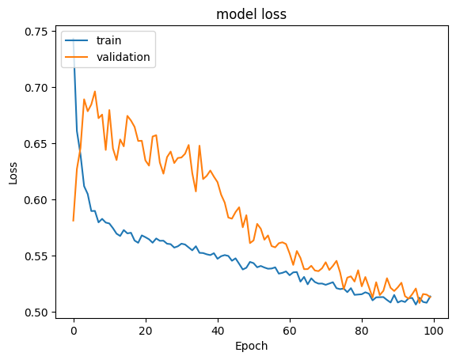

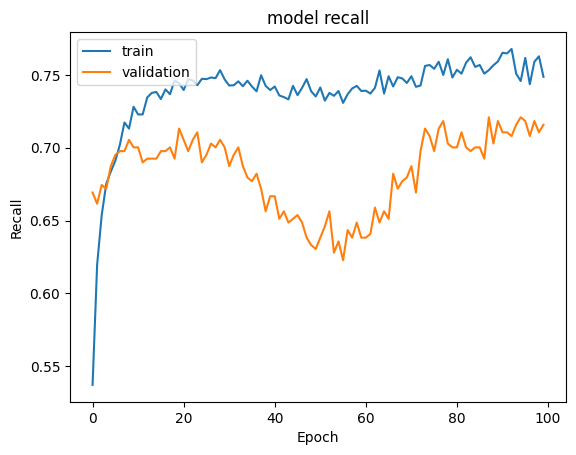

```python
# Plot the graphs
#Plot Train Loss vs Validation Loss
plt.plot(history_5.history['loss'])
plt.plot(history_5.history['val_loss'])
plt.title('model loss')
plt.ylabel('Loss')
plt.xlabel('Epoch')
plt.legend(['train', 'validation'], loc='upper left')
plt.show()

#Plotting Train recall vs Validation recall
plt.plot(history_5.history['recall'])
plt.plot(history_5.history['val_recall'])
plt.title('model recall')
plt.ylabel('Recall')
plt.xlabel('Epoch')
plt.legend(['train', 'validation'], loc='upper left')
plt.show()
```

```python
# Get the performance scores and collate them into the results dataframe

#Call the  utility function to get performance metrics and confusion matrix , round them and save them in the results df
p_scores_model_5_train, cm_scores_model_5_train = Get_model_Performace_metrics_and_confusion_matrix(model_5,X_train_over,y_train_over)
p_scores_model_5_val, cm_scores_model_5_val = Get_model_Performace_metrics_and_confusion_matrix(model_5,X_val,y_val)

p_scores_model_5_train = [round(x,2) for x in p_scores_model_5_train]
cm_scores_model_5_train = [round(x,2) for x in cm_scores_model_5_train]
p_scores_model_5_val = [round(x,2) for x in p_scores_model_5_val]
cm_scores_model_5_val = [round(x,2) for x in cm_scores_model_5_val]

results_df.loc[5] = [5,"NN with SMOTE data, ADAM, Dropout, BatchNormalization and Xavier initialization",3,"[128,dropout(0.75),128,dropout(0.75),128,dropout(0.75),64]",'tanh',
                    100,32,history_5.history["loss"][-1],history_5.history["val_loss"][-1],
                    p_scores_model_5_train,p_scores_model_5_val,
                    cm_scores_model_5_train,cm_scores_model_5_val,
                      cm_scores_model_5_train[2]*100/sum(cm_scores_model_5_train),cm_scores_model_5_val[2]*100/sum(cm_scores_model_5_val),
                     round(end-start,2)]
```

## Model Performance Comparison and Final Model Selection

```python
# Show the final summary for model performance comaparison and final model selection
results_df
```

|  | Model No. | Model Name | # of hidden layers | No. of neurons in hidden layers | Activation func | No. of epochs | Batch size | Train loss | Val loss | Train performance score [Acc, Recall, Precision, F1] | Val performance score [Acc, Recall, Precision, F1] | Train confusion matrix [TN, FP, FN, TP] | Val confusion matrix [TN, FP, FN, TP] | FN %-Train set | FN %-Val set | Time Taken (secs) |
| --- | --- | --- | --- | --- | --- | --- | --- | --- | --- | --- | --- | --- | --- | --- | --- | --- |
| 0 | 0 | NN with SGD | 2 | [64, 32] | relu | 100 | 32 | 0.434101 | 0.435346 | [0.8, 0.08, 0.61, 0.13] | [0.8, 0.06, 0.53, 0.12] | [4476, 56, 1074, 88] | [1490, 22, 362, 25] | 18.861960 | 19.062665 | 83.60 |
| 1 | 1 | NN with ADAM | 2 | [64, 32] | relu | 100 | 32 | 0.239275 | 0.411671 | [0.91, 0.7, 0.84, 0.76] | [0.84, 0.55, 0.63, 0.59] | [4374, 158, 352, 810] | [1387, 125, 175, 212] | 6.181946 | 9.215377 | 82.96 |
| 2 | 2 | NN with ADAM and Drop-out | 3 | [128,dropout(0.5),64,dropout(0.5),32] | relu | 100 | 32 | 0.314484 | 0.359958 | [0.88, 0.54, 0.82, 0.65] | [0.85, 0.51, 0.69, 0.59] | [4394, 138, 530, 632] | [1422, 90, 189, 198] | 9.308044 | 9.952607 | 64.71 |
| 3 | 3 | NN with SMOTE data and SGD | 3 | [128,64,32] | relu | 100 | 32 | 0.522195 | 0.543268 | [0.75, 0.76, 0.75, 0.75] | [0.72, 0.7, 0.4, 0.51] | [3358, 1174, 1099, 3433] | [1104, 408, 118, 269] | 12.124890 | 6.213797 | 83.08 |
| 4 | 4 | NN with SMOTE data and ADAM | 3 | [128,64,32] | relu | 100 | 32 | 0.083418 | 1.118810 | [0.98, 0.99, 0.96, 0.98] | [0.77, 0.59, 0.45, 0.51] | [4334, 198, 28, 4504] | [1237, 275, 159, 228] | 0.308914 | 8.372828 | 78.62 |
| 5 | 5 | NN with SMOTE data, ADAM, Dropout, BatchNormal... | 3 | [128,dropout(0.75),128,dropout(0.75),128,dropo... | tanh | 100 | 32 | 0.513623 | 0.512975 | [0.78, 0.78, 0.79, 0.78] | [0.77, 0.72, 0.45, 0.56] | [3589, 943, 1012, 3520] | [1179, 333, 110, 277] | 11.165049 | 5.792522 | 205.47 |

```python
# Finally test Model-5 on the test set

p_scores_model_5_test, cm_scores_model_5_test = Get_model_Performace_metrics_and_confusion_matrix(model_5,X_test,y_test)

print("Test performance scores of model-5:",p_scores_model_5_test)
print("Confusion matrix scores of model-5 on test set:", cm_scores_model_5_test)
print("FN % of model-5 on test set:",cm_scores_model_5_test[2]*100/sum(cm_scores_model_5_test))
```

```
Test performance scores of model-5: [0.7546076882569773, 0.6640826873385013, 0.433389544688027, 0.5244897959183674]
Confusion matrix scores of model-5 on test set: [1176, 336, 130, 257]
FN % of model-5 on test set: 6.845708267509216
```

## Actionable Insights and Business Recommendations

Following are some of the key insights and recommendations for close review and consideration by the bank:

- We know that 26% of customers who are 'not active' have exited the bank (vs 14% of customer who are active have exited). Given only 51% customers are active members and a resonably big chunk of 49% customers are inactive the bank needs to create targetted marketing campaigns to engage the customer and keep them active.
- Age is the highest positively correlated column with the 'Exited' column.median age of customers being higher in exited customers, Customer age spans from 18 to 92 with mean at ~39 and median at 37. The campaign to that extent should target older customers.
- More than 34% of customers have zero dollar balance in their accounts. The Bank can create campaigns to provide attractive interest rates & other incentives to have customer have higher balances in their accounts.
- Germany has the highest percentage of exited customers (32%), and Germany represents ~25% of the total customer base. To this extent the marketing campaigns can be targetted towards german population.
- Given females form relatively higher share of exited customers vs males at 25% vs 16% for males, they should form a higher priority in the campaign design.
- wrt other parameters, NumOfProducts owned by customers, their Tenure, their CreditScore, them having credit cards (or not) and their Estimated Salary showed no perceivable influence on whether they will exit or not. To that extent the campaign design can deprioritize these parameters.

In all the campaign should prioritize targetting Germany customers who are females and median age is higher than 40 years.

Finally, Model-5 should be deployed on expediated basis and predictions be used to make targetted margeting campaigns to 'risky' customers. The model's performane on the test set is resonable at 66% recall score and 6.8% false negative. The model scores can be further improved by increasing the complexity of the NN architecture based on the processing power (and correspondingly the increased cost) the client wants to invest in. The model prediction-output should be monitored routinely and feature adjustments should made on an on going basis as the banks evolves its business including in managing its customers better based on the insights and recommendations provided above.

Power Ahead